# Rank-normalized split-Rhat and relative efficiency estimates

We check the indicator function `I` and `lp__`:

```r
res <- monitor_simple(samp[, , 51:52])
cat('I: r_eff = ', round(res['I','reff'],2), '\n')
```

```
I: r_eff =  0.16
```

```r
cat('lp__: r_eff = ', round(res['lp__','zsreff'],2), '\n')
```

```
lp__: r_eff =  0.04
```

We examine the relative efficiency in different parts of the posterior, by computing the relative efficiency for $p(\hat{Q}_\alpha \le x < \hat{Q}_{\alpha+0.05})$, where $\hat{Q}_\alpha$ is $\alpha$-quantile and $\alpha \in (0,0.05,\ldots,0.95)$ in steps of $0.05$.

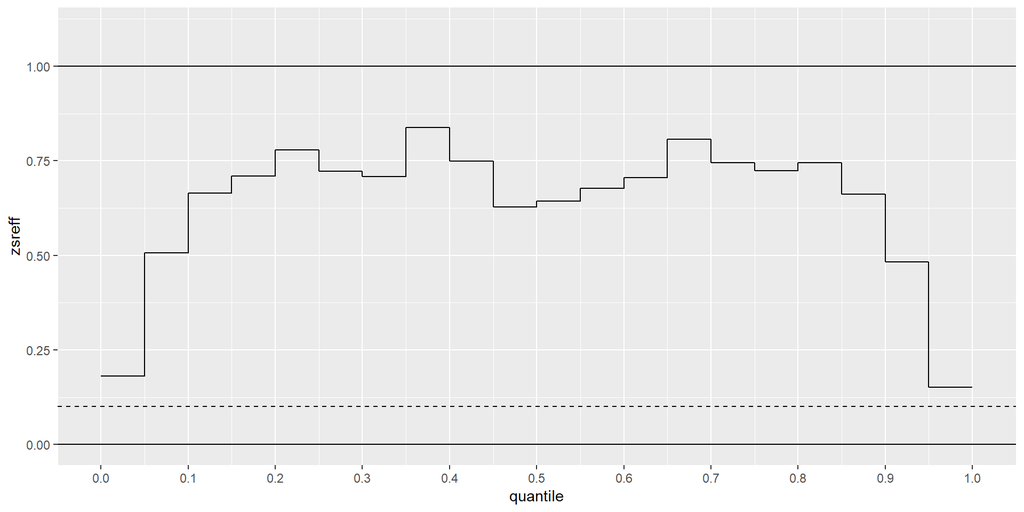

```r
plot_local_reff(samp = samp, par = 1, nalpha = 20)
```

Increasing chain length did not seem to change the relative efficiency. With more draws from the longer chains we can use finer resolution for the local efficiency estimates.

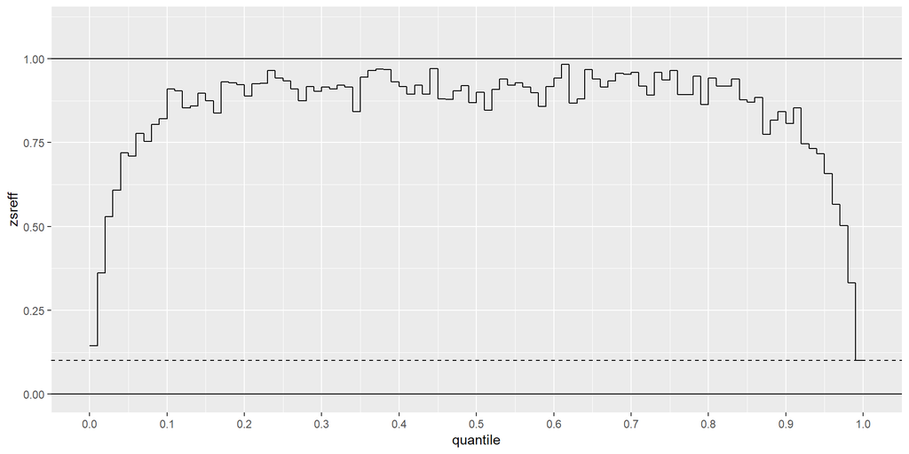

```r
plot_local_reff(samp = samp, par = 1, nalpha = 100)
```

The efficiency far in the tails is worryingly low. We see similar problems in the alternative local relative efficiency.

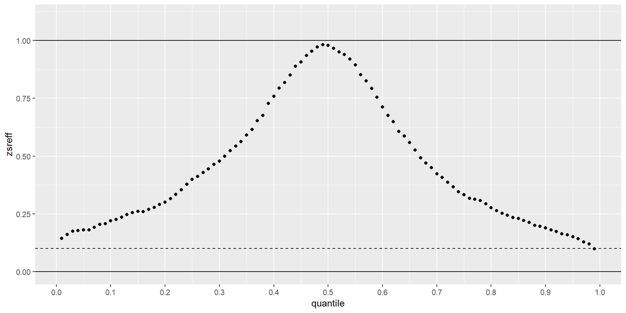

```r
plot_quantile_reff(samp = samp, par = 1, nalpha = 100)
```

The rank plot visualisation of x[39], which has the smallest relative efficiency 0.04 among the x’s.

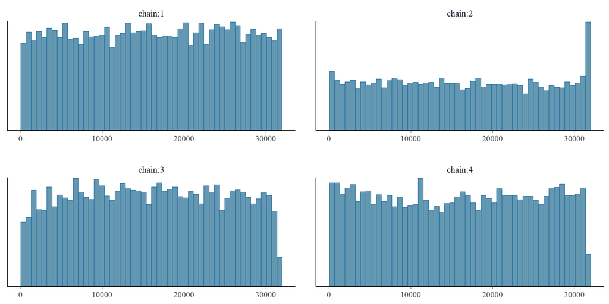

```r
xmin <- paste0("x[", which_min_eff, "]")
mcmc_hist_r_scale(samp[, , xmin])
```

Still problems at the edges.

The rank plot visualisation of `lp__`, which has relative efficiency 0.04, looks as follows:

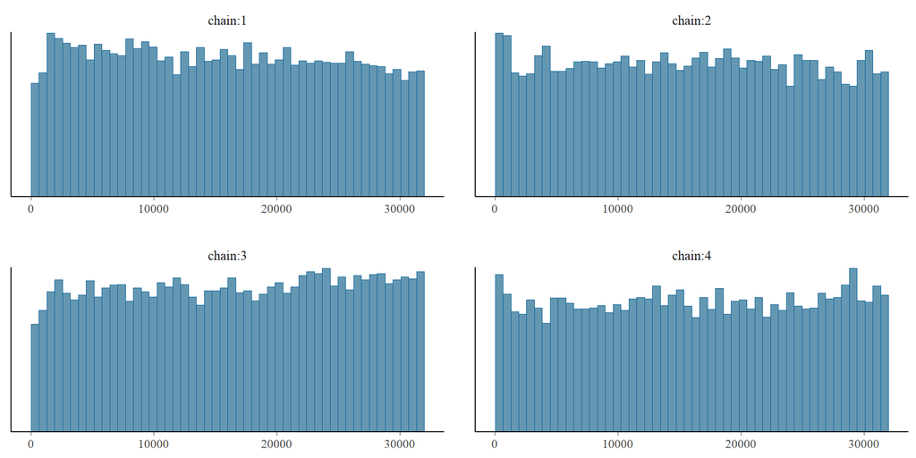

```r
mcmc_hist_r_scale(samp[, , "lp__"])
```

There seems to be slight problems also in mixing for energy.

### 4.3.2 First alternative parameterization of Cauchy

Next we examine alternative parameterization and consider Cauchy as a scale mixture of Gaussian distributions. The model has two parameters and the Cauchy distributed x’s can be computed from those. In addition of improved sampling performance, the example illustrates that focus of diagnostics matter.

```r
writeLines(readLines("cauchy_alt_1.stan"))
```

```
parameters {
  vector[50] x_a;
  vector<lower=0>[50] x_b;
}

transformed parameters {
  vector[50] x = x_a ./ sqrt(x_b);
}

model {
  x_a ~ normal(0, 1);
  x_b ~ gamma(0.5, 0.5);
}

generated quantities {
  real I = fabs(x[1]) < 1 ? 1 : 0;
}
```

Run the alternative model:

```r
fit_alt1 <- stan(file='cauchy_alt_1.stan', seed=7878, refresh = 0)
```

```r
samp <- as.array(fit_alt1)
res <- monitor_simple(samp[, , 101:150])
```

There are no warnings, and the sampling is much faster.

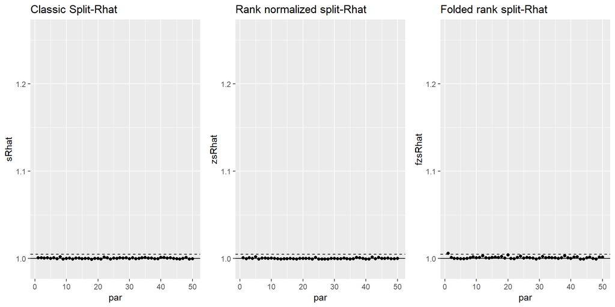

```r
plot_rhat(res)
```

All Rhats are below 1.01. Classic Rhat’s look also good even if the classic is not well defined for Cauchy distribution.

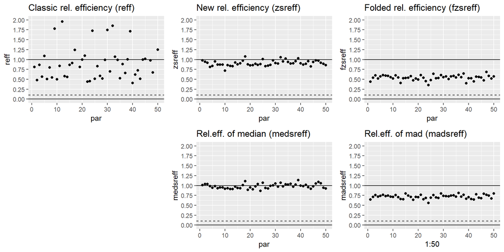

```r
plot_reff(res)
```

**Result:** Rank normalized r_eff’s have less variation than classic one which is not well defined for Cauchy.

We check the indicator function `I` and `lp__`:

```r
res <- monitor_simple(samp[, , 151:152])
cat('I: r_eff = ', round(res['I','zsreff'], 2), '\n')
```

```
I: r_eff =  0.66
```

```r
cat('lp__: r_eff = ', round(res['lp__','zsreff'], 2), '\n')
```

```
lp__: r_eff =  0.33
```

The relative efficiency for these are also much better than with nominal parameterization.

We examine the relative efficiency in different parts of the posterior, by computing the relative efficiency for $p(\hat{Q}_\alpha \le x < \hat{Q}_{\alpha + 0.05})$, where $\hat{Q}_\alpha$ is $\alpha$-quantile and $\alpha \in (0,0.05,\ldots,0.95)$.

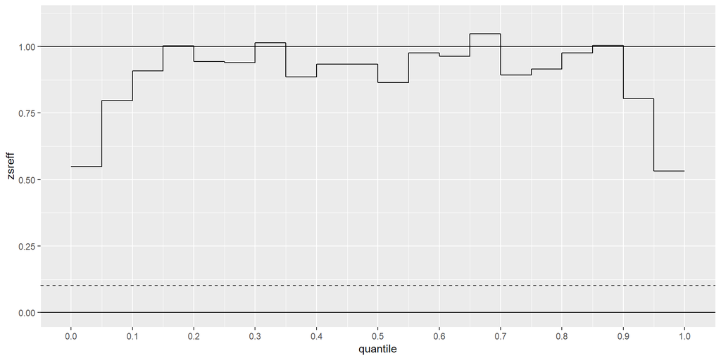

```r
samp <- as.array(fit_alt1)
plot_local_reff(samp = samp, par = 101, nalpha = 20)
```

The relative efficiency is good in all parts of the posterior.

We examine the relative efficiency in different parts of the posterior, by computing the relative efficiency for $p(x < \hat{Q}_{\alpha})$, where $\hat{Q}_\alpha$ is $\alpha$-quantile and $\alpha \in (0,0.025,\ldots,0.975)$.

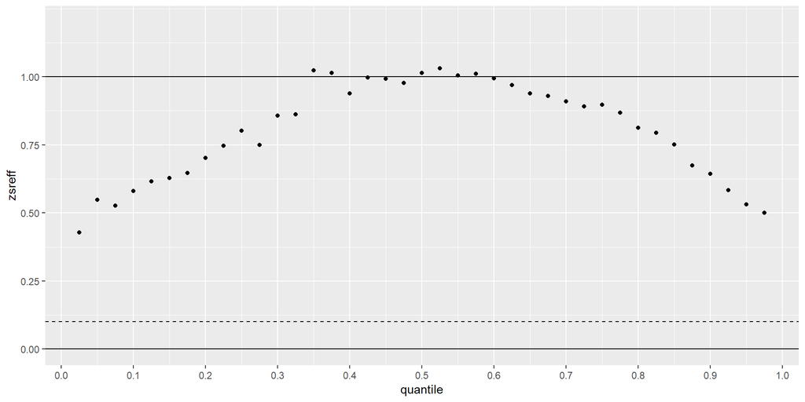

```r
samp <- as.array(fit_alt1)
plot_quantile_reff(samp = samp, par = 101, nalpha = 40)
```

```r
res <- monitor_simple(samp[, , 101:150])
which_min_eff <- which(res$zsreff == min(res$zsreff))
res1 <- monitor_simple(samp[, , 1:50])
res2 <- monitor_simple(samp[, , 51:100])
```

```r
cat('Mean r_eff for xs = ' , round(mean(res[,'zsreff']), 2), '\n')
```

```
Mean r_eff for xs =  0.91
```

```r
cat('Mean fr_eff for xs = ' , round(mean(res[,'fzsreff']), 2), '\n')
```

```
Mean fr_eff for xs =  0.54
```

```r
cat('Mean r_eff for x_as = ' , round(mean(res1[,'zsreff']), 2), '\n')
```

```
Mean r_eff for x_as =  0.99
```

```r
cat('Mean r_eff for x_bs = ' , round(mean(res2[,'zsreff']), 2), '\n')
```

```
Mean r_eff for x_bs =  0.69
```

**Result:** We see that the relative efficiency of the interesting $x$ can be different from the relative efficiency of the parameters that used to compute it. Also r_eff we are computing is for rank normalized and to compute Monte Carlo errors, the final target function should be taken into account, but we just want to avoid the complication of the potentially non-existing moments at this point, and come back later in other paper how to use Pareto diagnostic to check whether necessary moments exist to compute the desired expectations and their Monte Carlo errors.

Rank plot visualisation of x[10], which has the smallest relative efficiency 0.72 among x’s.

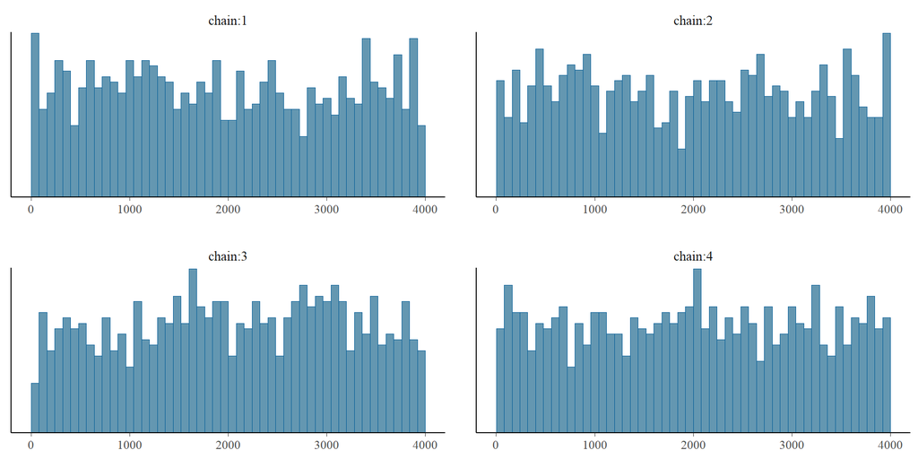

```r
xmin <- paste0("x[", which_min_eff, "]")
mcmc_hist_r_scale(samp[, , xmin])
```

Looks better than for the nominal parameterization.

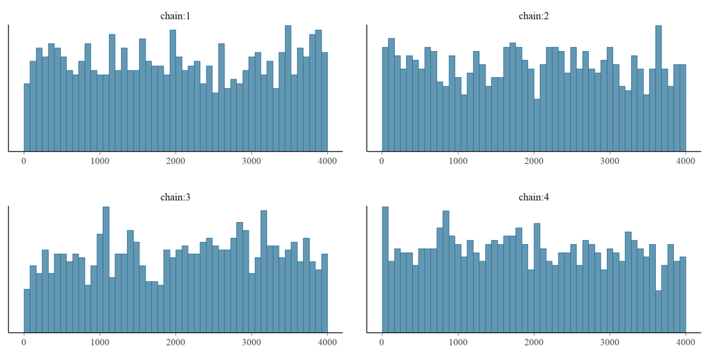

```r
mcmc_hist_r_scale(samp[, , "lp__"])
```

Looks better than for the nominal parameterization. It would be useful to have the reference plotted.

### 4.3.3 Another alternative parameterization of the Cauchy distribution

Another alternative parameterization is univariate transformation as shown in the following code (3rd alternative in Michael Betancourt’s case study).

```r
writeLines(readLines("cauchy_alt_3.stan"))
```

```
parameters {
  vector<lower=0, upper=1>[50] x_tilde;
}

transformed parameters {
vector[50] x = tan(pi() * (x_tilde - 0.5));
}

model {
  // Implicit uniform prior on x_tilde
}

generated quantities {
  real I = fabs(x[1]) < 1 ? 1 : 0;
}
```

Run the alternative model:

```r
fit_alt3 <- stan(file='cauchy_alt_3.stan', seed=7878, refresh = 0)
```

There are no warnings, and the sampling is much faster than for the nominal model.

```r
samp <- as.array(fit_alt3)
res <- monitor_simple(samp[, , 51:100])
```

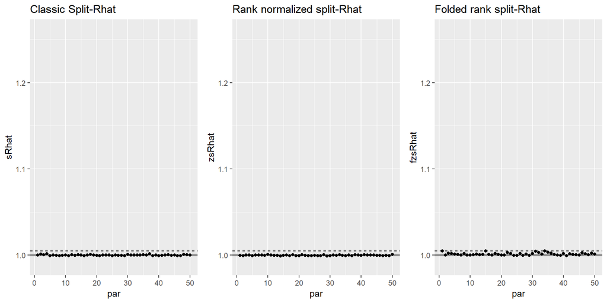

```r
plot_rhat(res)
```

All Rhats except some folded Rhats are below 1.01. Classic Rhat’s look also good even if it is not well defined for the Cauchy distribution.

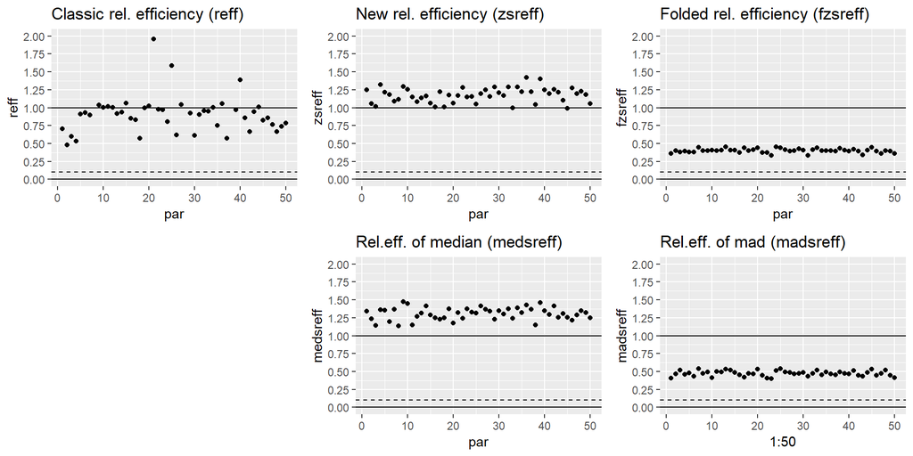

```r
plot_reff(res)
```

**Result:** Rank normalized relative efficiencies have less variation than classic ones which is not well defined for Cauchy. Rank normalized relative efficiencies are slightly larger than 1, which is possible for antithetic Markov chains which have negative correlation for odd lags.

We check the indicator function `I` and `lp__`:

```r
res <- monitor_simple(samp[, , 101:102])
cat('I: r_eff = ', round(res['I','zsreff'],2), '\n')
```

```
I: r_eff =  0.4
```

```r
cat('lp__: r_eff = ', round(res['lp__','zsreff'],2), '\n')
```

```
lp__: r_eff =  0.37
```

The relative efficiency for these are also much better than with the nominal parameterization.

We examine the relative efficiency in different parts of the posterior, by computing the relative efficiency for $p(\hat{Q}_\alpha \leq x < \hat{Q}_{\alpha+0.05})$, where $\hat{Q}_\alpha$ is $\alpha$-quantile and $\alpha \in (0,0.05,\ldots,0.95)$.

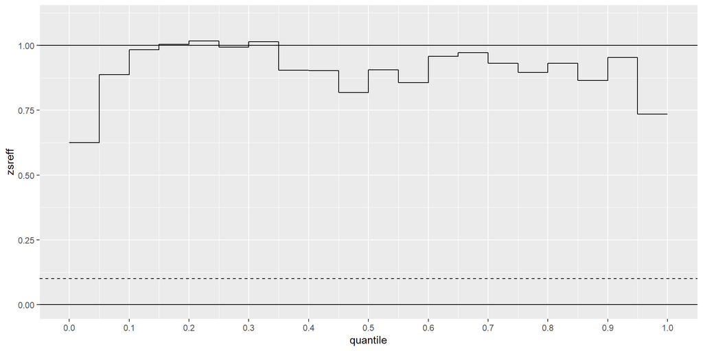

```r
samp <- as.array(fit_alt3)
plot_local_reff(samp = samp, par = 51, nalpha = 20)
```

We examine the relative efficiency in different parts of the posterior, by computing the relative efficiency for $p(x < \hat{Q}_{\alpha})$, where $\hat{Q}_\alpha$ is $\alpha$-quantile and $\alpha \in (0,0.025,\ldots,0.975)$.

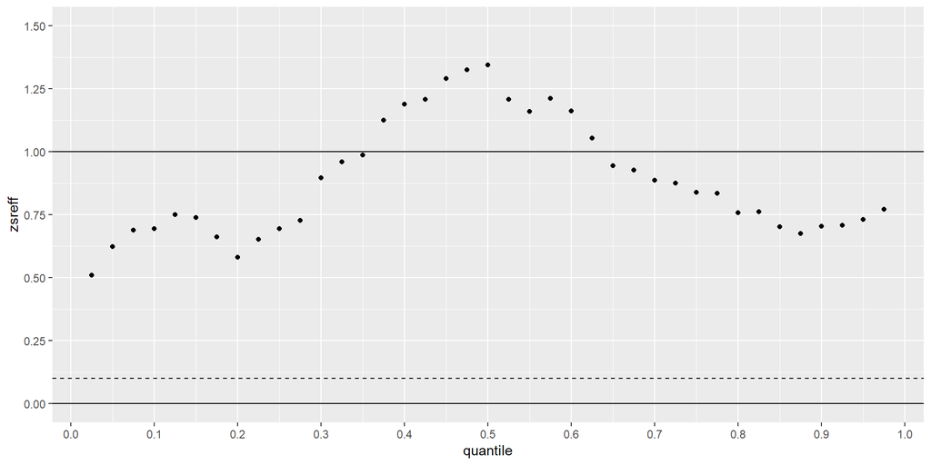

```r
samp <- as.array(fit_alt3)
plot_quantile_reff(samp = samp, par = 51, nalpha = 40)
```

```r
res <- monitor_simple(samp[, , 51:100])
which_min_eff <- which(res$zsreff == min(res$zsreff))
res1 <- monitor_simple(samp[, , 1:50])
cat('Mean r_eff for xs = ' , round(mean(res[,'zsreff']),2), '\n')
```

```
Mean r_eff for xs =  1.18
```

```r
cat('Mean fr_eff for xs = ' , round(mean(res[,'fzsreff']),2), '\n')
```

```
Mean fr_eff for xs =  0.4
```

```r
cat('Mean r_eff for x_as = ' , round(mean(res1[,'zsreff']),2), '\n')
```

```
Mean r_eff for x_as =  1.18
```

**Result:** When the transformation is univariate and bijective, the rank normalized Rhat and r_eff are transformation invariant.

Naturally when computing the desired expectations, the final target function should be taken into account, but we just want to avoid the complication of the potentially non-existing moments at this point, and come back later in other paper how to use Pareto diagnostic to check whether necessary moments exist to compute the desired expectations and their Monte Carlo errors.

Rank plot visualisation of x[45], which has the smallest relative efficiency of 0.99 among x’s.

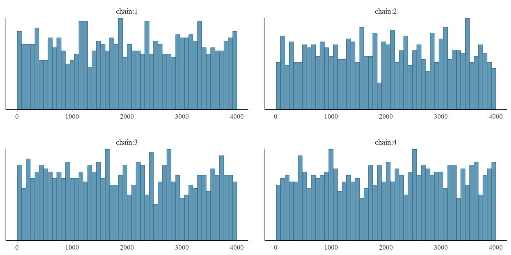

```r
xmin <- paste0("x[", which_min_eff, "]")
mcmc_hist_r_scale(samp[, , xmin])
```

Nothing special.

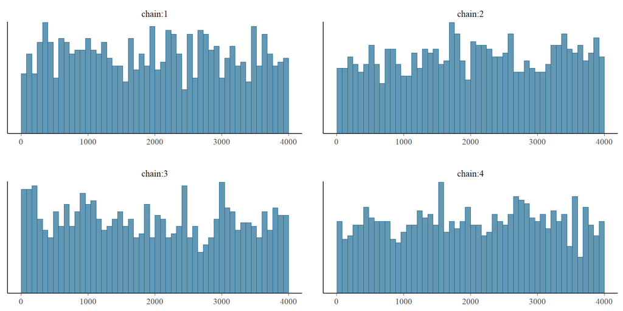

```r
mcmc_hist_r_scale(samp[, , "lp__"])
```

Nothing special.

### 4.3.4 Half-Cauchy with nominal parameterization

Half-Cauchy priors are common and, for example, in Stan usually set using the nominal parameterization. However, when the constraint `<lower=0>` is used, Stan does the sampling automatically in the unconstrained `log(x)` space, which changes the geometry crucially.

```r
writeLines(readLines("half_cauchy_nom.stan"))
```

```
parameters {
  vector<lower=0>[50] x;
}

model {
  x ~ cauchy(0, 1);
}

generated quantities {
  real I = fabs(x[1]) < 1 ? 1 : 0;
}
```

Run the half-Cauchy with nominal parameterization (and positive constraint).

```r
fit_half_nom <- stan(file='half_cauchy_nom.stan', seed=7878, refresh = 0)
```

There are no warnings, and the sampling is much faster than for the Cauchy nominal model.

```r
samp <- as.array(fit_half_nom)
res <- monitor_simple(samp[, , 1:50])
```

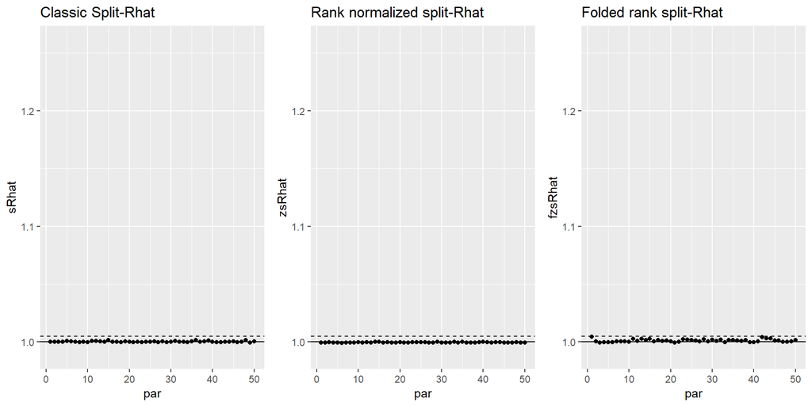

```r
plot_rhat(res)
```

All Rhats are below 1.01. Classic Rhat’s look also good even if the classic is not well defined for half-Cauchy distribution.

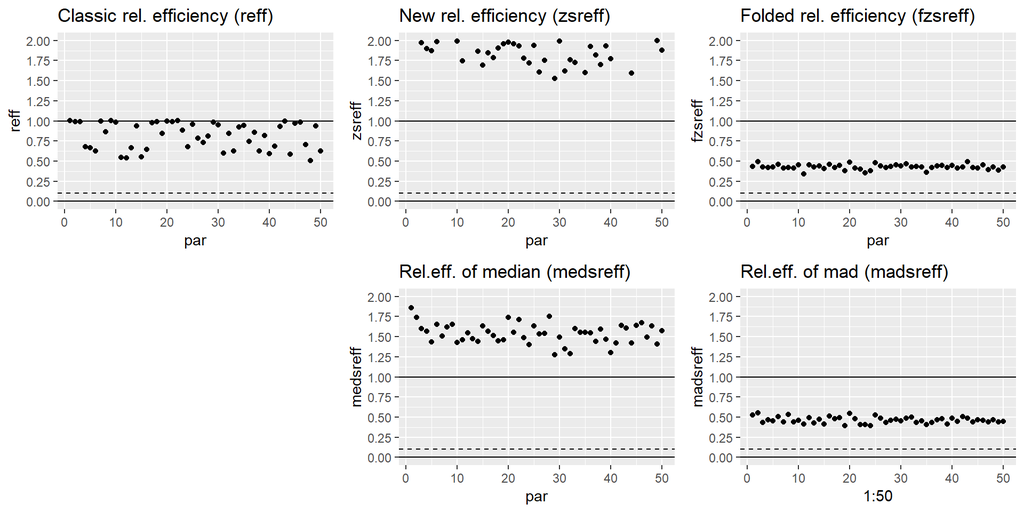

```r
plot_reff(res)
```

**Result:** Rank normalized r_eff’s have less variation than classic one which is not well defined for Cauchy. Rank normalized r_eff’s are much larger than 1, which is possible for antithetic Markov chains which have negative correlation for odd lags.

Due to constraint `<lower=0>`, the sampling was made in `log(x)` space, and we can also check the performance in that space.

```r
res <- monitor_simple(samp[, , 1:50])
```

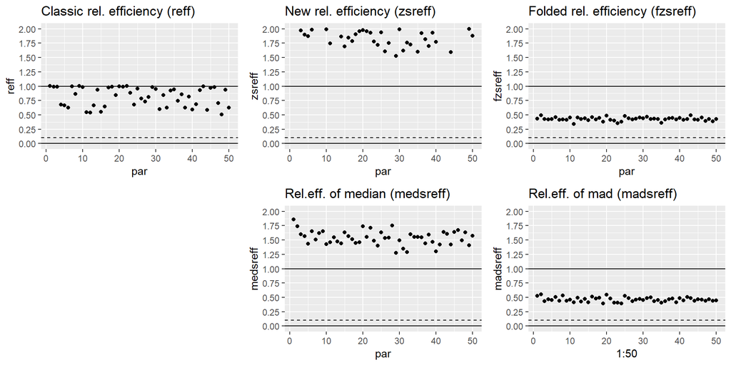

```r
plot_reff(res)
```

We check the indicator function `I` and `lp__`:

```r
res <- monitor_simple(samp[, , 51:52])
which_min_eff <- which(res$zsreff == min(res$zsreff))
cat('I: r_eff = ', round(res['I','zsreff'],2), '\n')
```

```
I: r_eff =  1.84
```

```r
cat('lp__: r_eff = ', round(res['lp__','zsreff'],2), '\n')
```

```
lp__: r_eff =  0.3
```

**Result:** Relative efficiency for $p(x_1 < 1)$ is larger than 1. This is possible for antithetic Markov chains, which have negative correlation for odd lags.

We examine the relative efficiency in different parts of the posterior, by computing the relative efficiency for $p(\hat{Q}_\alpha \le x < \hat{Q}_{\alpha+0.05})$, where $\hat{Q}_\alpha$ is $\alpha$-quantile and $\alpha \in (0,0.05,\ldots,0.95)$.

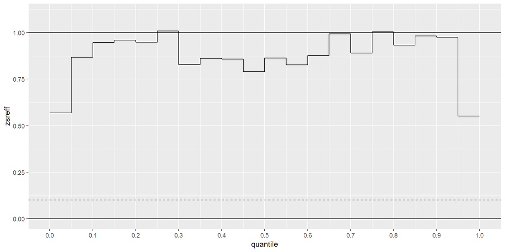

```r
samp <- as.array(fit_half_nom)
plot_local_reff(samp = samp, par = 1, nalpha = 20)
```

The relative efficiency is good overall, with only a small dip in tails.

We examine the relative efficiency in different parts of the posterior, by computing the relative efficiency for $p(x < \hat{Q}_{\alpha+0.05})$, where $\hat{Q}_\alpha$ is $\alpha$-quantile and $\alpha \in (0,0.025,\ldots,0.975)$.

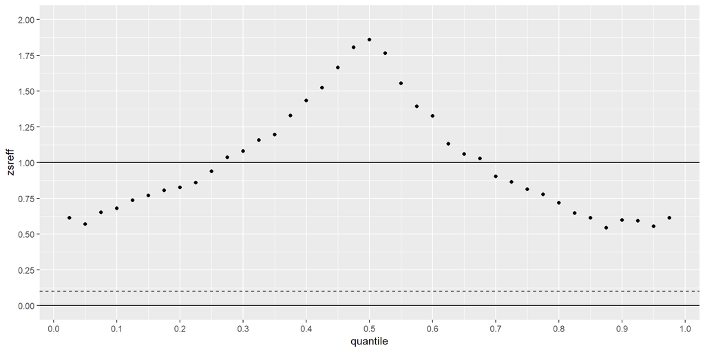

```r
samp <- as.array(fit_half_nom)
plot_quantile_reff(samp = samp, par = 1, nalpha = 40)
```

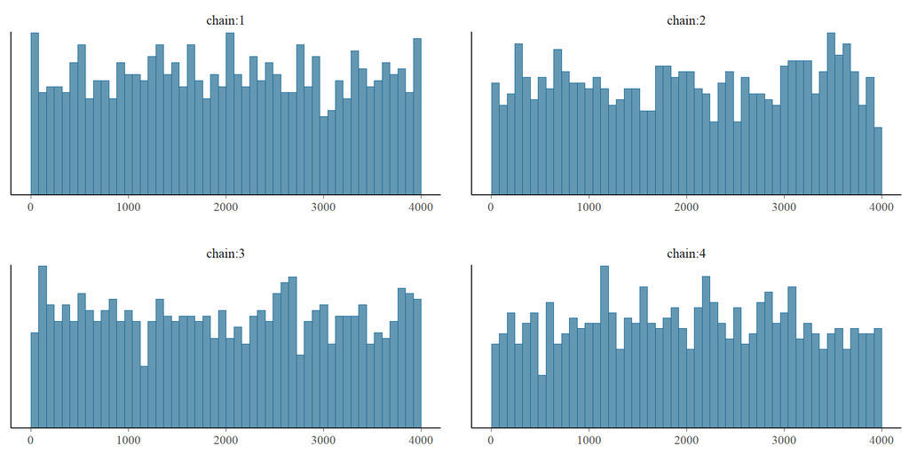

```r
xmin <- paste0("x[", which_min_eff, "]")
mcmc_hist_r_scale(samp[, , xmin])
```

Looks like there are differences in scale of chains.

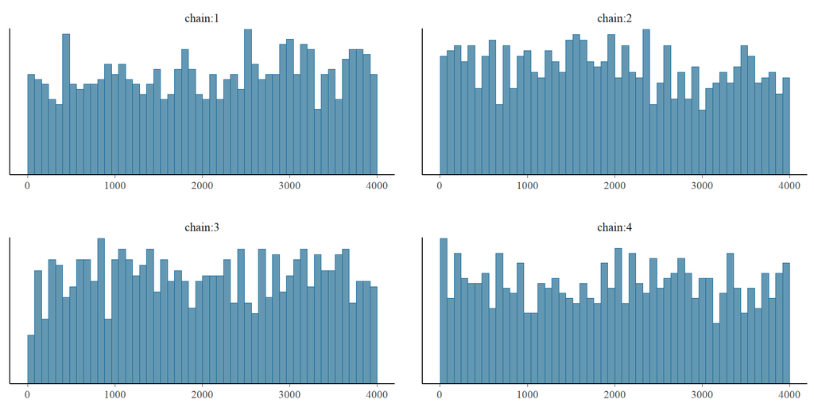

```r
mcmc_hist_r_scale(samp[, , "lp__"])
```

Maybe small differences in scales, but it’s difficult to know whether small variation from uniform is relevant.

### 4.3.5 Alternative parameterization of half-Cauchy

```r
writeLines(readLines("half_cauchy_alt.stan"))
```

```
parameters {
  vector<lower=0>[50] x_a;
  vector<lower=0>[50] x_b;
}

transformed parameters {
  vector[50] x = x_a .* sqrt(x_b);
}

model {
  x_a ~ normal(0, 1);
  x_b ~ inv_gamma(0.5, 0.5);
}

generated quantities {
  real I = fabs(x[1]) < 1 ? 1 : 0;
}
```

Run half-Cauchy with alternative parameterization

```r
fit_half_reparam <- stan(file = 'half_cauchy_alt.stan', seed=7878, refresh = 0)
```

There are no warnings, and the sampling is as fast for the half-Cauchy nominal model.

```r
samp <- as.array(fit_half_reparam)
res <- monitor_simple(samp[, , 101:150])
```

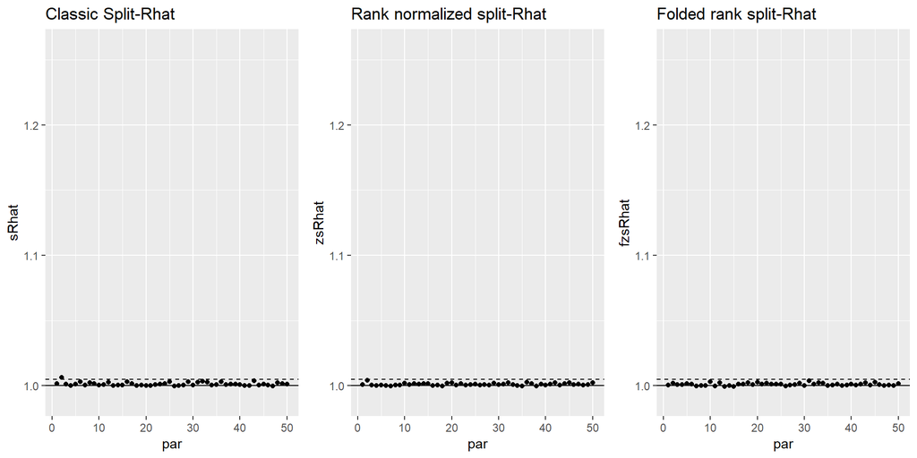

```r
plot_rhat(res)
```

All Rhats are below 1.01. Classic Rhat’s look also good even if the classic is not well defined for half-Cauchy distribution.

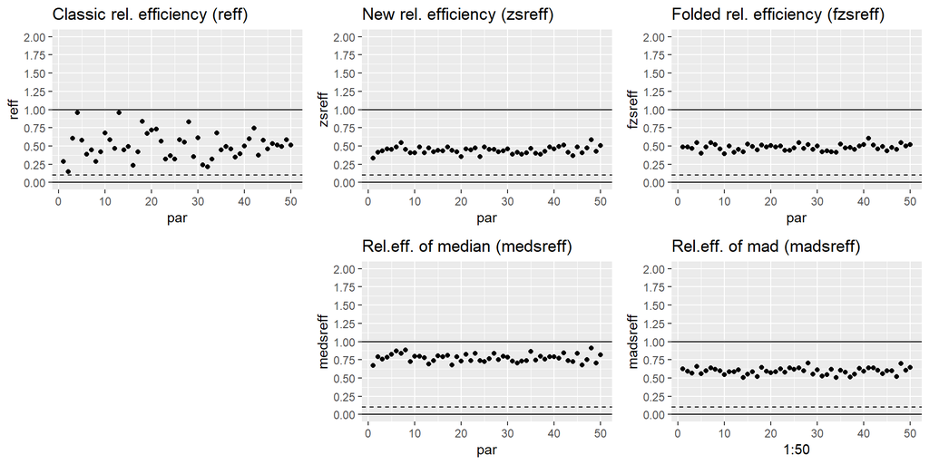

```r
plot_reff(res)
```

**Result:** Rank normalized relative efficiencies have less variation than classic ones which is not well defined for Cauchy. Based on rank normalized relative efficiencies the alternative parameterization has much lower efficiency than the nominal parameterization with constraint `<lower=0>`.

We check the indicator function `I` and `lp__`:

```r
res <- monitor_simple(samp[, , 151:152])
cat('I: r_eff = ', round(res['I','zsreff'],2), '\n')
```

```
I: r_eff =  0.67
```

```r
cat('lp__: r_eff = ', round(res['lp__','zsreff'],2), '\n')
```

```
lp__: r_eff =  0.24
```

We examine the relative efficiency in different parts of the posterior, by computing the relative efficiency for $p(\hat{Q}_\alpha \le x < \hat{Q}_{\alpha+0.05})$, where $\hat{Q}_\alpha$ is $\alpha$-quantile and $\alpha \in (0,0.05,\ldots,0.95)$.

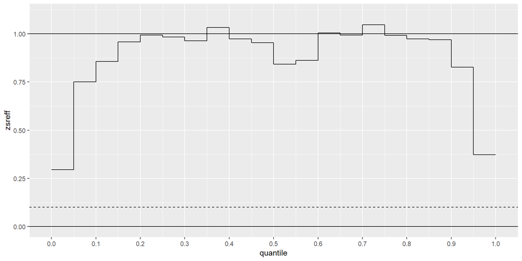

```r
samp <- as.array(fit_half_reparam)
plot_local_reff(samp = samp, par = 101, nalpha = 20)
```

We examine the relative efficiency in different parts of the posterior, by computing the relative efficiency for $p(x < \hat{Q}_{\alpha+0.05})$, where $\hat{Q}_\alpha$ is $\alpha$-quantile and $\alpha \in (0,0.025,\ldots,0.975)$.

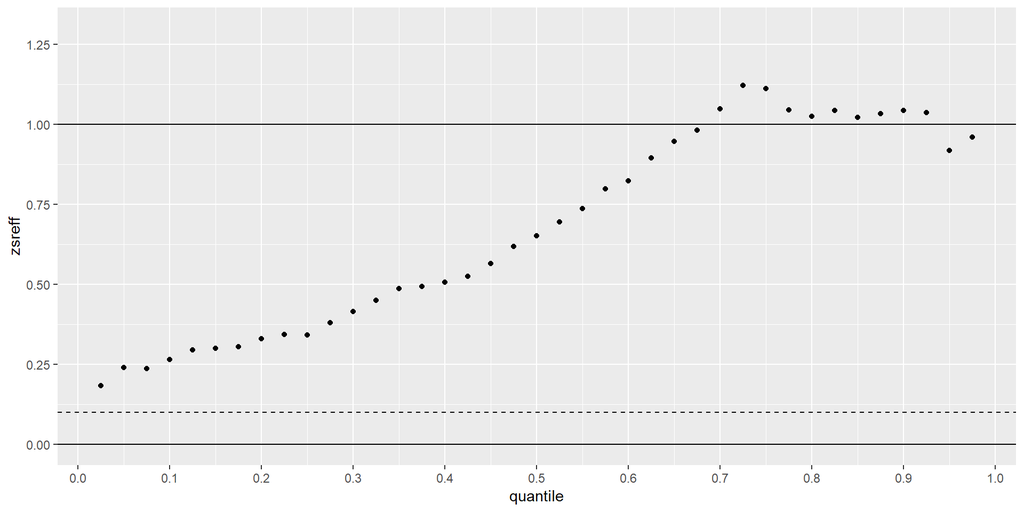

```r
samp <- as.array(fit_half_reparam)
plot_quantile_reff(samp = samp, par = 1, nalpha = 40)
```

The relative efficiency near zero is much worse than for the half-Cauchy with nominal parameterization and constraint `<lower=0>`.

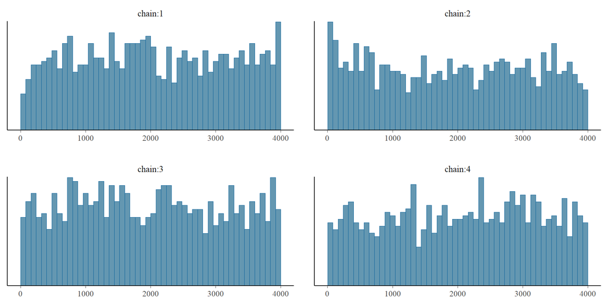

```r
mcmc_hist_r_scale(samp[, , "x[15]"])
```

The rank plot is different from uniform, which is expected with lower relative efficiency, but would require a reference.

Rank plot visualisation of `lp__`, which has relative efficiency 0.24.

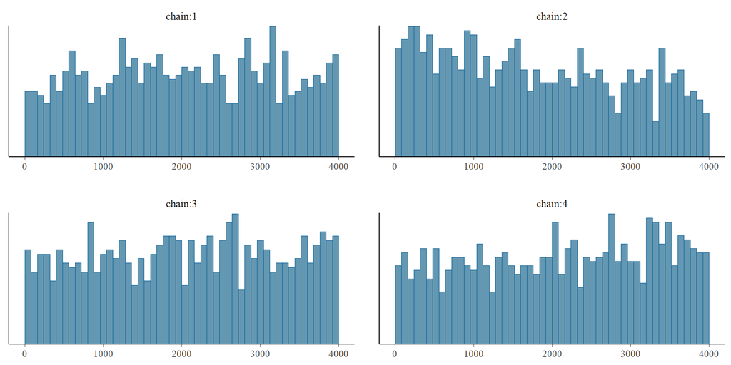

```r
mcmc_hist_r_scale(samp[, , "lp__"])
```

The rank plot is different from uniform, which is expected with lower relative efficiency, but would require a reference.

## 4.4 Hierarchical model: Eight Schools

The models are from Michael Betancourt’s case study on [Diagnosing Biased Inference with Divergences](http://mc-stan.org/users/documentation/case-studies/divergences_and_bias.html).

### 4.4.1 A Centered Eight Schools model

```r
writeLines(readLines("eight_schools_cp.stan"))
```

```
data {
  int<lower=0> J;
  real y[J];
  real<lower=0> sigma[J];
}

parameters {
  real mu;
  real<lower=0> tau;
  real theta[J];
}

model {
  mu ~ normal(0, 5);
  tau ~ cauchy(0, 5);
  theta ~ normal(mu, tau);
  y ~ normal(theta, sigma);
}
```

#### 4.4.1.1 Centered parameterization default MCMC options

Run centered parameterization model with default MCMC options.

```r
input_data <- read_rdump("eight_schools.data.R")
fit_cp <- stan(
  file='eight_schools_cp.stan', data=input_data,
  iter=2000, chains=4, seed=483892929, refresh=0
)
```

We do observe divergent transitions, which is sensitive diagnostic for this model and we observer also low BFMI, but let’s assume we were investigating a MCMC algorithm without such diagnostic.

```r
sel <- c(
  'sRhat', 'zsRhat', 'fzsRhat', 'reff',
  'zsreff', 'fzsreff', 'medsreff', 'madsreff'
)
res <- monitor_simple(fit_cp)
round(res[, sel], 2)
```

```
         sRhat zsRhat fzsRhat reff zsreff fzsreff medsreff madsreff
mu        1.00   1.00    1.01 0.15   0.15    0.05     0.13     0.09
tau       1.01   1.03    1.00 0.06   0.03    0.21     0.08     0.11
theta[1]  1.00   1.00    1.01 0.22   0.21    0.05     0.13     0.10
theta[2]  1.00   1.00    1.02 0.22   0.21    0.04     0.13     0.10
theta[3]  1.00   1.00    1.01 0.30   0.28    0.06     0.13     0.11
theta[4]  1.00   1.00    1.02 0.24   0.22    0.05     0.14     0.09
theta[5]  1.00   1.00    1.01 0.27   0.25    0.11     0.14     0.11
theta[6]  1.00   1.00    1.02 0.29   0.27    0.05     0.11     0.08
theta[7]  1.00   1.00    1.01 0.18   0.17    0.12     0.09     0.10
theta[8]  1.00   1.00    1.01 0.27   0.24    0.08     0.15     0.10
lp__      1.04   1.04    1.02 0.02   0.03    0.05     0.07     0.12
```

Some rank-normalized split-Rhats are larger than 1.01. Relative efficiencies for tau and lp__ are less than 10%, which is worry-some and longer chains should be run.

We examine the relative efficiency of probabilities between quantiles (0, 0.05, …, 1) for `tau`.

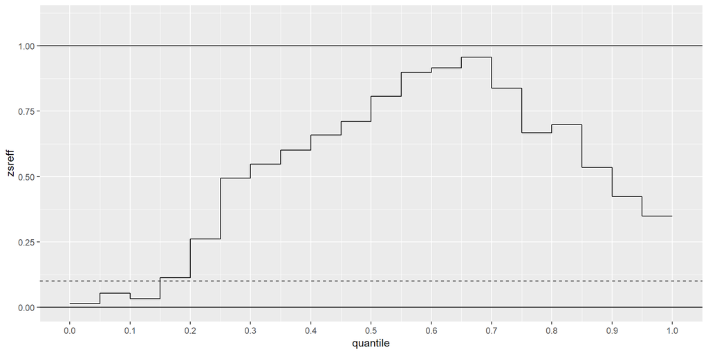

```r
samp <- as.array(fit_cp)
plot_local_reff(samp = samp, par = "tau", nalpha = 20)
```

We see that MCMC has difficulties in exploring small tau values. As the efficiency for estimating small tau values is practically zero, we may assume that we may miss substantial amount of posterior mass and get biased estimates.

We examine the relative efficiency of cumulative probabilities below quantiles $(0.025, ..., 0.975)$ for `tau`.

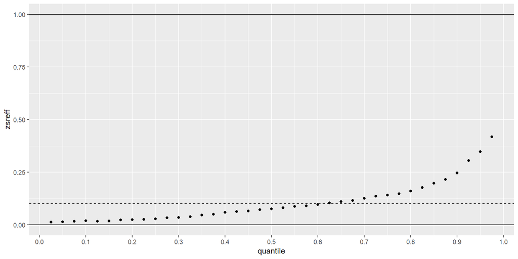

```r
samp <- as.array(fit_cp)
plot_quantile_reff(samp = samp, par = 2, nalpha = 40)
```

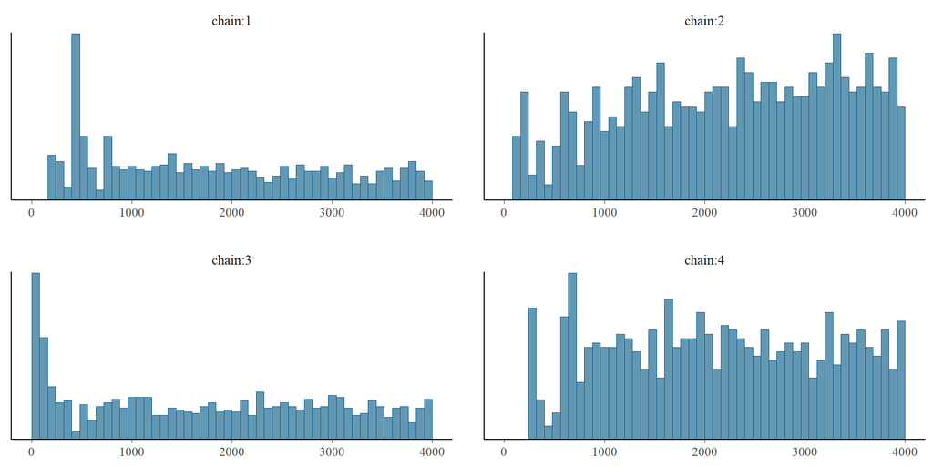

```r
mcmc_hist_r_scale(samp[, , "tau"])
```

We observe clear problems.

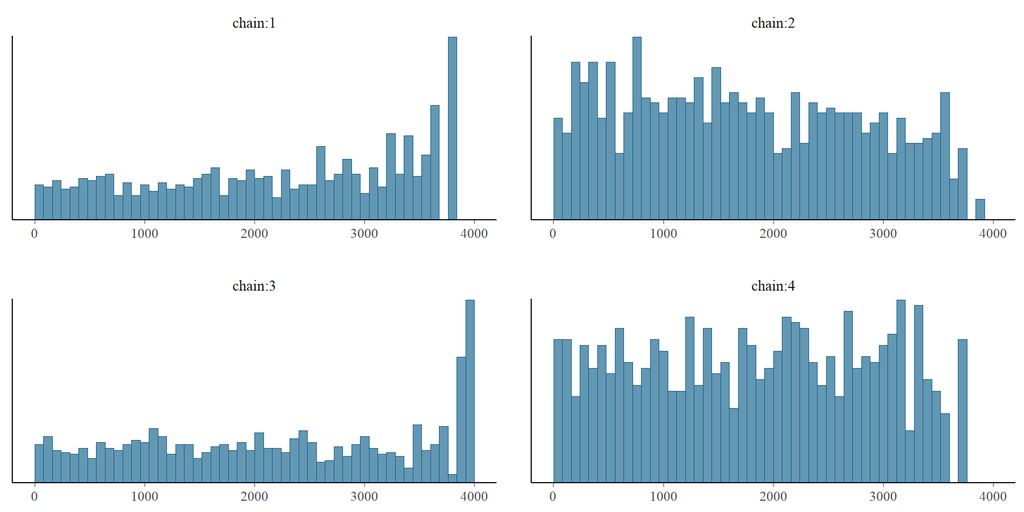

```r
mcmc_hist_r_scale(samp[, , "lp__"])
```

We observe clear problems.

#### 4.4.1.2 Centered parameterization with longer chains

Low r_eff can be sometimes compensated with longer chains. Let’s check 10 times longer chain.

```r
fit_cp2 <- stan(
  file='eight_schools_cp.stan', data=input_data,
  iter=20000, chains=4, seed=483892929, refresh=0
)
res <- monitor_simple(fit_cp2)
round(res[, sel], 2)
```

```
         sRhat zsRhat fzsRhat reff zsreff fzsreff medsreff madsreff
mu        1.00   1.00       1 0.03   0.03    0.08     0.06     0.09
tau       1.00   1.01       1 0.04   0.01    0.16     0.05     0.07
theta[1]  1.00   1.00       1 0.07   0.05    0.09     0.06     0.07
theta[2]  1.00   1.00       1 0.06   0.05    0.12     0.06     0.07
theta[3]  1.00   1.00       1 0.13   0.10    0.17     0.06     0.08
theta[4]  1.00   1.00       1 0.08   0.07    0.15     0.05     0.08
theta[5]  1.00   1.00       1 0.13   0.11    0.17     0.06     0.08
theta[6]  1.00   1.00       1 0.09   0.08    0.15     0.06     0.08
theta[7]  1.00   1.00       1 0.05   0.04    0.08     0.07     0.07
theta[8]  1.00   1.00       1 0.09   0.07    0.14     0.06     0.07
lp__      1.01   1.01       1 0.02   0.02    0.03     0.05     0.07
```

Some rank-normalized split-Rhats are still larger than 1.01. Relative efficiencies for tau and `lp__` are around 1%. A drop in the relative efficiency when increasing the number of iterations indicates serious problems in mixing.

We examine the relative efficiency of probabilities between quantiles $(0, 0.05, ..., 1)$ for `tau`.

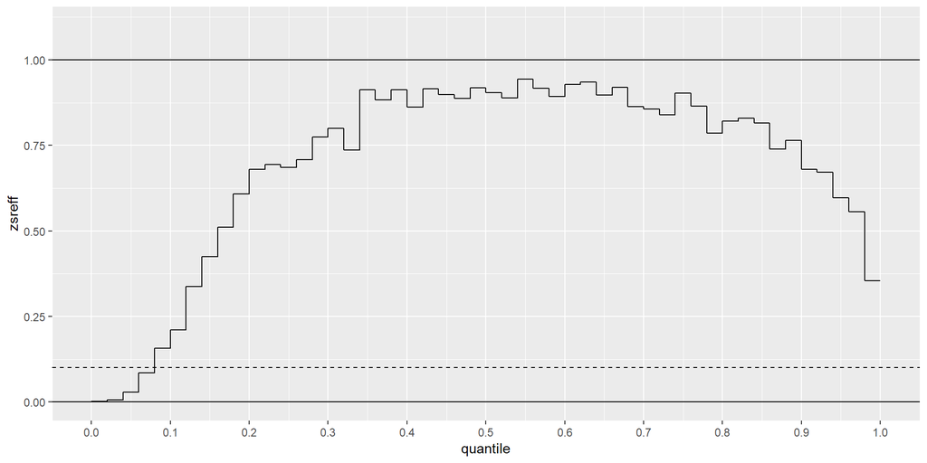

```r
samp <- as.array(fit_cp2)
plot_local_reff(samp = samp, par = 2, nalpha = 50)
```

We see that MCMC has difficulties in exploring small `tau` values. As the efficiency for estimating small `tau` values is practically zero, we may assume that we may miss substantial amount of posterior mass and get biased estimates.

We examine the relative efficiency of cumulative probabilities below quantiles $(0.01, ..., 0.99)$ for `tau`.

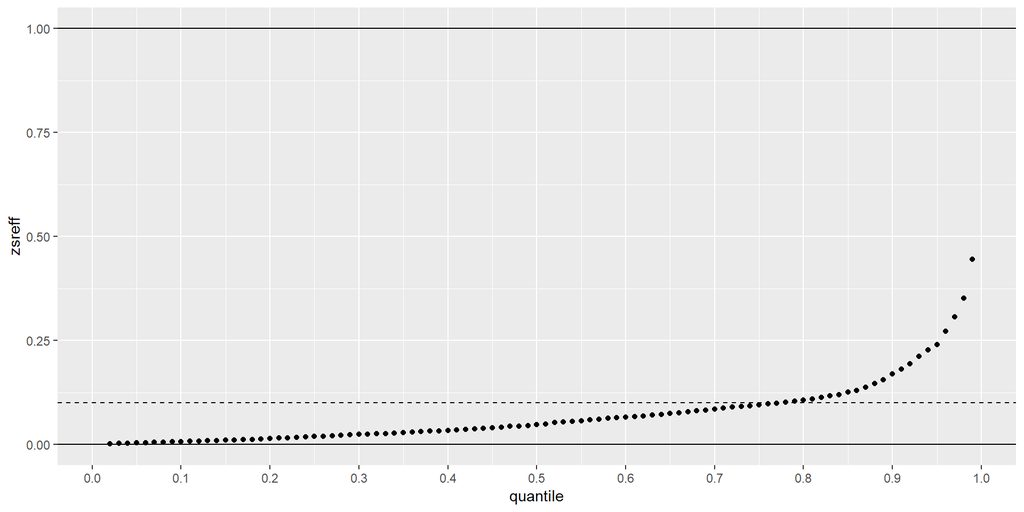

```r
samp <- as.array(fit_cp2)
plot_quantile_reff(samp = samp, par = 2, nalpha = 100)
```

We examine also other parameters, like `mu` in the following plot.

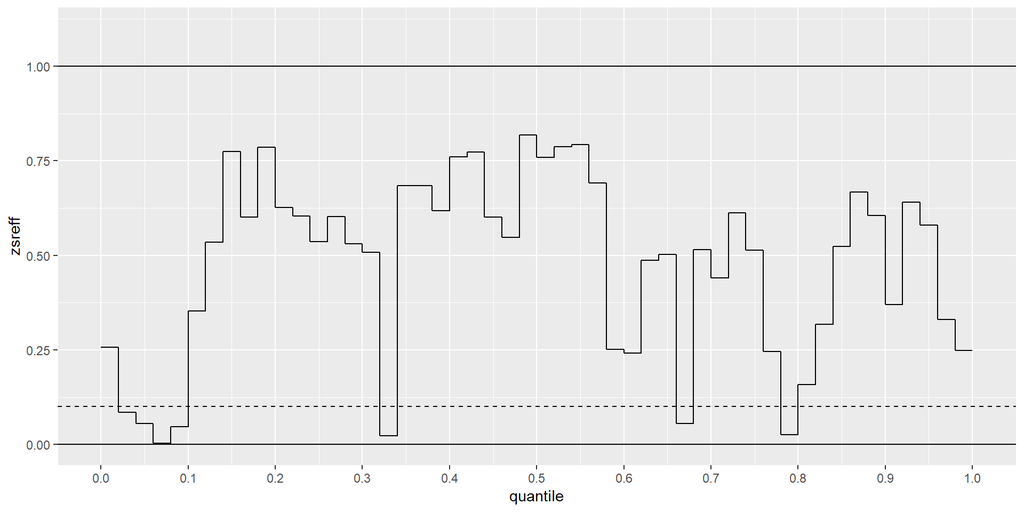

```r
samp <- as.array(fit_cp2)
plot_local_reff(samp = samp, par = 1, nalpha = 50)
```

There are gaps of poor efficiency which indicates sticking of MCMC, but the sticking doesn’t occur for any specific range of values of `mu`.

We examine also other parameters, like `mu` in the following plot.

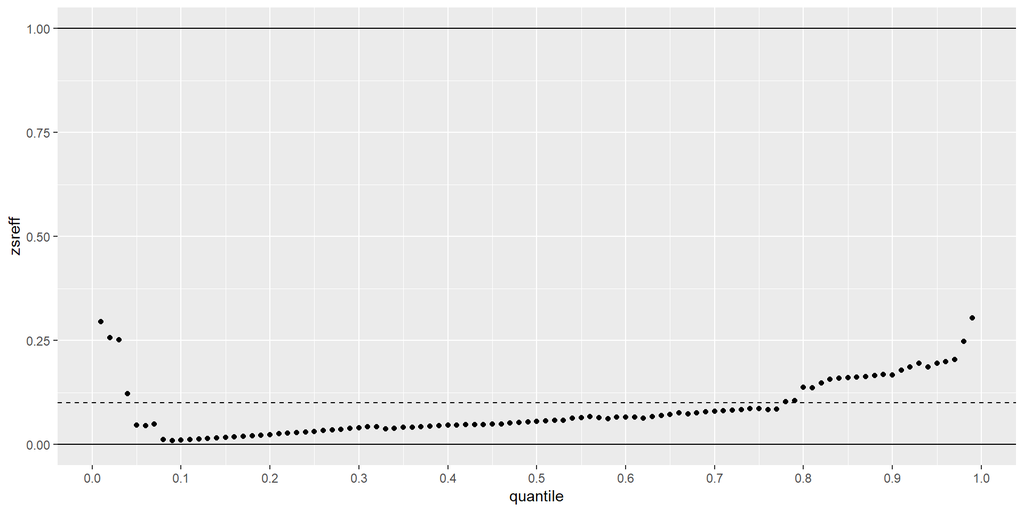

```r
samp <- as.array(fit_cp2)
plot_quantile_reff(samp = samp, par = 1, nalpha = 100)
```

Rank plot visualisation of `tau`, which has the smallest relative efficiency 0.01 among parameters.

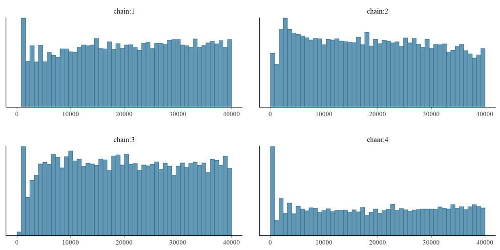

```r
mcmc_hist_r_scale(samp[, , "tau"])
```

We observe clear problems to sample small values of tau.

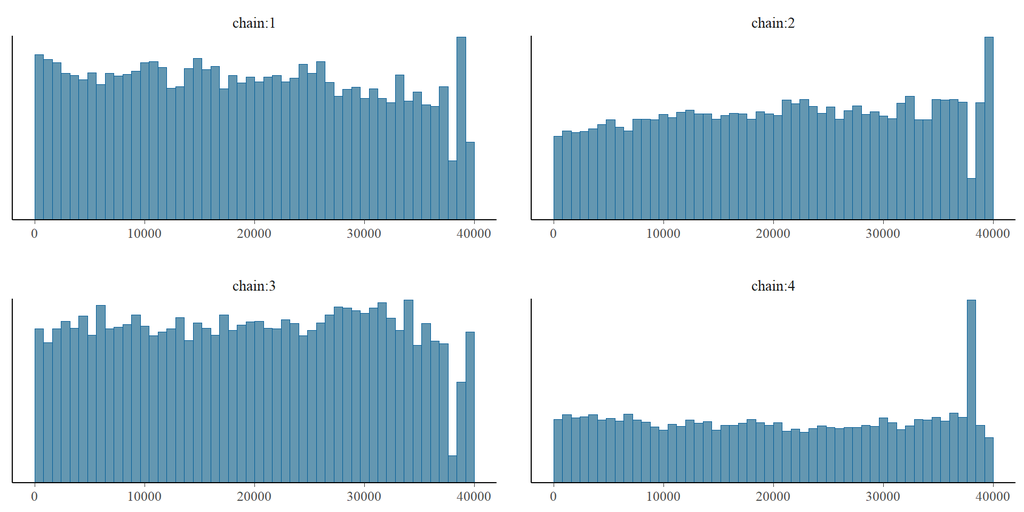

```r
mcmc_hist_r_scale(samp[, , "lp__"])
```

We observe clear problems sampling different energy levels.

#### 4.4.1.3 Centered parameterization very long chains

And for further evidence let’s check 100 times longer chains than the default.

```r
fit_cp3 <- stan(
  file='eight_schools_cp.stan', data=input_data,
  iter=200000, chains=4, seed=483892929, refresh=0
)
res <- monitor_simple(fit_cp3)
round(res[, sel], 2)
```

```
         sRhat zsRhat fzsRhat reff zsreff fzsreff medsreff madsreff
mu           1      1       1 0.03   0.03    0.04     0.02     0.02
tau          1      1       1 0.02   0.00    0.05     0.02     0.02
theta[1]     1      1       1 0.05   0.04    0.04     0.02     0.02
theta[2]     1      1       1 0.06   0.05    0.03     0.02     0.03
theta[3]     1      1       1 0.08   0.06    0.04     0.02     0.02
theta[4]     1      1       1 0.07   0.05    0.04     0.02     0.02
theta[5]     1      1       1 0.06   0.05    0.02     0.02     0.02
theta[6]     1      1       1 0.08   0.07    0.03     0.02     0.02
theta[7]     1      1       1 0.04   0.04    0.03     0.02     0.03
theta[8]     1      1       1 0.07   0.05    0.05     0.02     0.03
lp__         1      1       1 0.01   0.00    0.01     0.02     0.02
```

We examine the relative efficiency of probabilities between quantiles $(0, 0.05, ..., 1)$ for tau.

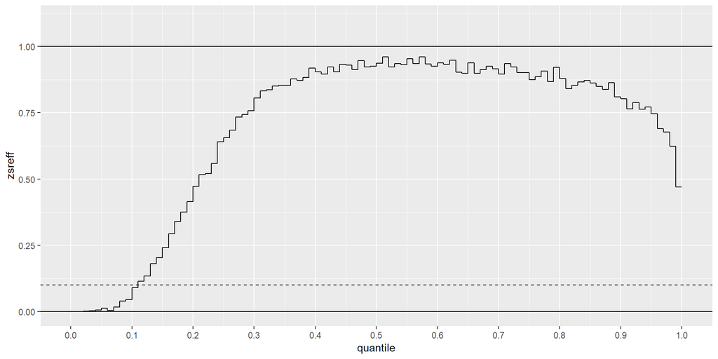

```r
samp <- as.array(fit_cp3)
plot_local_reff(samp = samp, par = 2, nalpha = 100)
```

We see that MCMC has difficulties in exploring small tau values. As the efficiency for estimating small tau values is practically zero, we may assume that we may miss substantial amount of posterior mass and get biased estimates. It is good to note that the low efficiency for small tau values is due to too large step size, and the low efficiency for large tau values is partially due to too small step size, but even more importantly due to the random walk in energy space.

We examine the relative efficiency of cumulative probabilities below quantiles (0.01, …, 0.99) for tau.

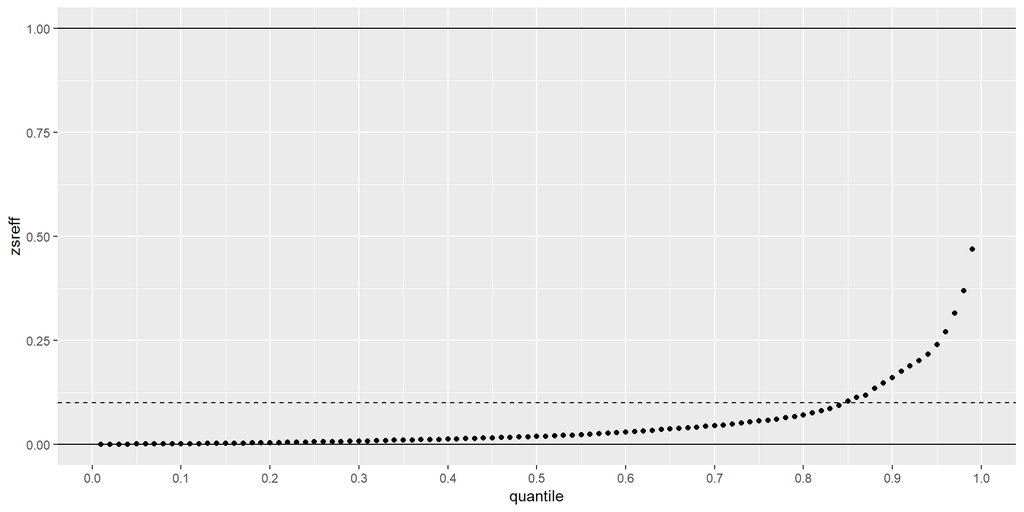

```r
samp <- as.array(fit_cp3)
plot_quantile_reff(samp = samp, par = 2, nalpha = 100)
```

Rank plot visualisation of tau, which has the smallest relative efficiency 0.00 among parameters.

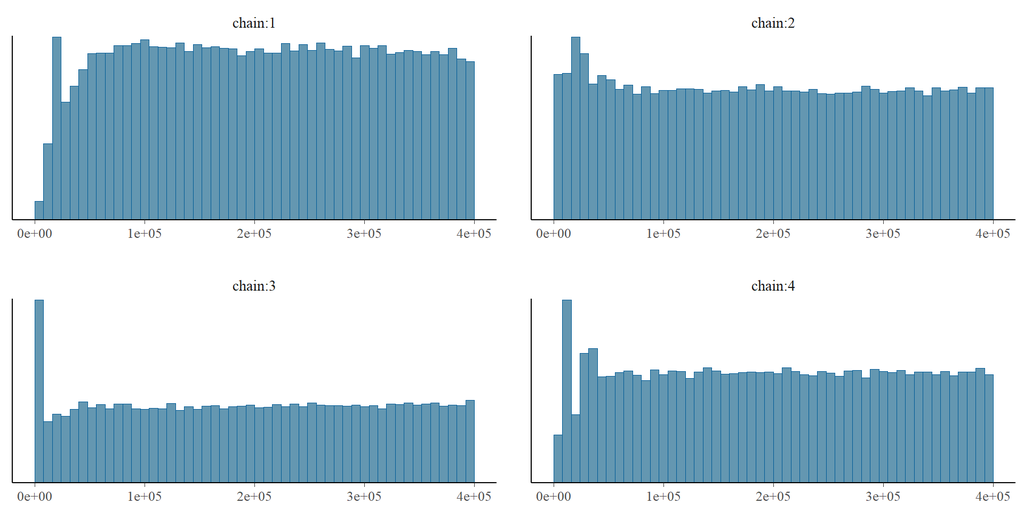

```r
mcmc_hist_r_scale(samp[, , 2])
```

We observe clear problems to sample small values of tau and even with 100000 draws per chain, the plots don’t get crowded as traceplots would.

Rank plot visualisation of lp__, which has relative efficiency 0.01.

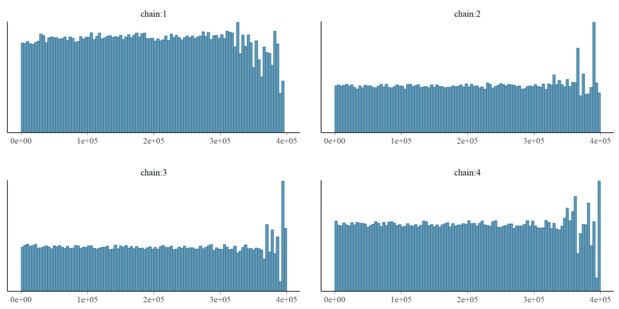

```r
mcmc_hist(r_scale(samp[,,11]), breaks = seq(0,prod(dim(samp)[1:2]),by=prod(dim(samp)[1:2])/100)+0.5)
```

We observe clear problems sampling different energy levels, and the low efficiency for lp__ comes just from slow random walk (autocorrelation for chains 1 and 2 goes to zero after 1000 lags, and for chains 3 and 4 after 5000 lags).

### 4.4.2 Non-centered Eight Schools model

For hierarchical models, non-centered parameterization often works better

```r
writeLines(readLines("eight_schools_ncp.stan"))
```

```
data {
  int<lower=0> J;
  real y[J];
  real<lower=0> sigma[J];
}

parameters {
  real mu;
  real<lower=0> tau;
  real theta_tilde[J];
}

transformed parameters {
  real theta[J];
  for (j in 1:J)
    theta[j] = mu + tau * theta_tilde[j];
}

model {
  mu ~ normal(0, 5);
  tau ~ cauchy(0, 5);
  theta_tilde ~ normal(0, 1);
  y ~ normal(theta, sigma);
}
```

#### 4.4.2.1 Non-centered parameterization default MCMC options

Run non-centered parameterization model with default options.

```r
input_data <- read_rdump("eight_schools.data.R")
fit_ncp <- stan(
  file='eight_schools_ncp.stan', data=input_data,
  iter=2000, chains=4, seed=483892929, refresh=0
)
```

We still observe some divergent transitions with the default adapt_delta and no divergences with adapt_delta=0.95. Let’s analyze both samples.

```r
res <- monitor_simple(fit_ncp)
round(res[, sel], 2)
```

```
               sRhat zsRhat fzsRhat reff zsreff fzsreff medsreff madsreff
mu                 1      1       1 1.01   1.02    0.44     1.06     0.59
tau                1      1       1 0.67   0.58    0.78     0.79     0.79
theta_tilde[1]     1      1       1 1.13   1.14    0.54     1.12     0.62
theta_tilde[2]     1      1       1 1.44   1.44    0.50     1.34     0.60
theta_tilde[3]     1      1       1 1.23   1.24    0.53     1.35     0.61
theta_tilde[4]     1      1       1 1.34   1.36    0.50     1.21     0.60
theta_tilde[5]     1      1       1 1.06   1.07    0.57     1.07     0.67
theta_tilde[6]     1      1       1 1.30   1.30    0.52     1.19     0.60
theta_tilde[7]     1      1       1 0.97   0.97    0.57     0.96     0.70
theta_tilde[8]     1      1       1 1.21   1.21    0.48     1.09     0.50
theta[1]           1      1       1 0.88   0.95    0.63     1.09     0.70
theta[2]           1      1       1 1.22   1.25    0.58     1.06     0.64
theta[3]           1      1       1 0.95   1.00    0.64     1.00     0.74
theta[4]           1      1       1 1.14   1.17    0.66     1.14     0.71
theta[5]           1      1       1 1.03   1.08    0.70     1.13     0.67
theta[6]           1      1       1 1.18   1.24    0.67     1.19     0.79
theta[7]           1      1       1 1.10   1.15    0.62     1.08     0.73
theta[8]           1      1       1 1.01   1.12    0.62     1.10     0.66
lp__               1      1       1 0.42   0.43    0.62     0.50     0.70
```

All Rhats are close to 1, and relative efficiencies are good.

We examine the relative efficiency of probabilities between quantiles $(0, 0.05, ..., 1)$ for tau.

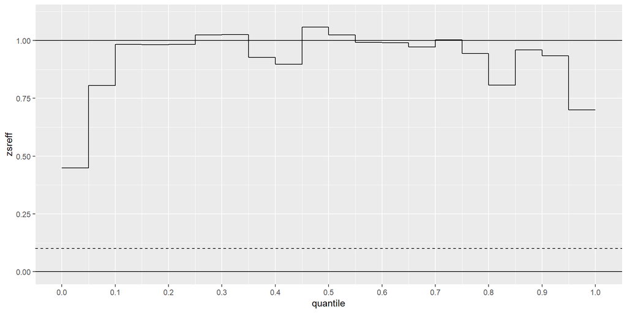

```r
samp <- as.array(fit_ncp)
plot_local_reff(samp = samp, par = 2, nalpha = 20)
```

Small tau values are still more difficult to explore, but the relative efficiency is in a good range.

We examine the relative efficiency of probabilities below quantiles (0.025, …, 0.975) for tau.

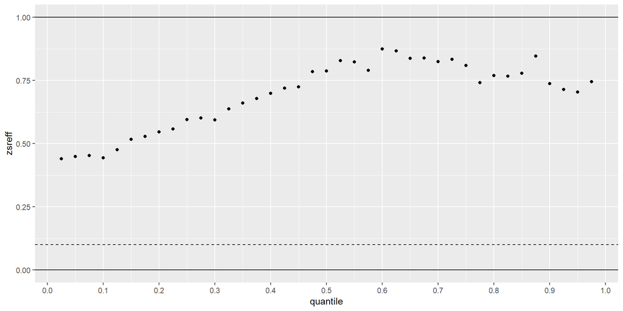

```r
samp <- as.array(fit_ncp)
plot_quantile_reff(samp = samp, par = 2, nalpha = 40)
```

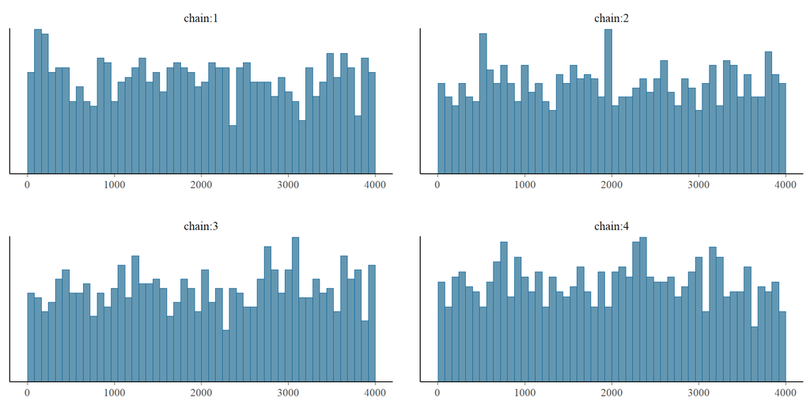

```r
mcmc_hist_r_scale(samp[, , 2])
```

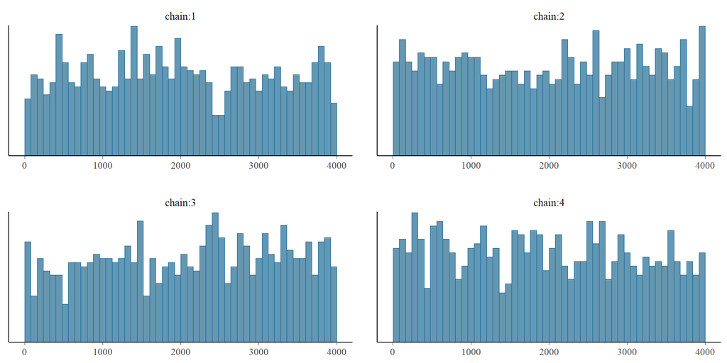

```r
mcmc_hist_r_scale(samp[, , 19])
```

We observe clear problems sampling different energy levels.

#### 4.4.2.2 Non-centered parameterization default MCMC options plus `adapt_delta=0.95`

Next we examine the same model but with higher `adapt_delta=0.95`.

```r
fit_ncp2 <- stan(
  file='eight_schools_ncp.stan', data=input_data,
  iter=2000, chains=4, control=list(adapt_delta = 0.95),
  seed=483892929, refresh=0
)
```

We get zero divergences with `adapt_delta = 0.95`.

```r
res <- monitor_simple(fit_ncp2)
round(res[, sel], 2)
```

```
               sRhat zsRhat fzsRhat reff zsreff fzsreff medsreff madsreff
mu                 1      1       1 1.38   1.38    0.52     1.34     0.65
tau                1      1       1 0.87   0.72    0.84     0.84     0.79
theta_tilde[1]     1      1       1 1.23   1.26    0.46     1.30     0.51
theta_tilde[2]     1      1       1 1.03   1.04    0.50     1.00     0.58
theta_tilde[3]     1      1       1 1.60   1.62    0.52     1.41     0.59
theta_tilde[4]     1      1       1 1.51   1.52    0.47     1.37     0.58
theta_tilde[5]     1      1       1 1.39   1.40    0.54     1.26     0.58
theta_tilde[6]     1      1       1 1.21   1.21    0.47     1.20     0.59
theta_tilde[7]     1      1       1 1.18   1.20    0.53     1.19     0.60
theta_tilde[8]     1      1       1 1.52   1.54    0.49     1.33     0.56
theta[1]           1      1       1 1.10   1.23    0.64     1.09     0.71
theta[2]           1      1       1 1.22   1.28    0.63     1.23     0.61
theta[3]           1      1       1 1.29   1.36    0.70     1.32     0.68
theta[4]           1      1       1 1.12   1.17    0.64     1.13     0.68
theta[5]           1      1       1 1.30   1.34    0.68     1.32     0.74
theta[6]           1      1       1 1.35   1.42    0.60     1.39     0.68
theta[7]           1      1       1 1.11   1.18    0.66     1.15     0.69
theta[8]           1      1       1 1.18   1.23    0.64     1.19     0.69
lp__               1      1       1 0.40   0.41    0.65     0.53     0.77
```

All Rhats are close to 1, and relative efficiencies are good and slightly better than with the default `adapt_delta`.

We examine the relative efficiency of probabilities between quantiles $(0, 0.05, ..., 1)$ for `tau`.

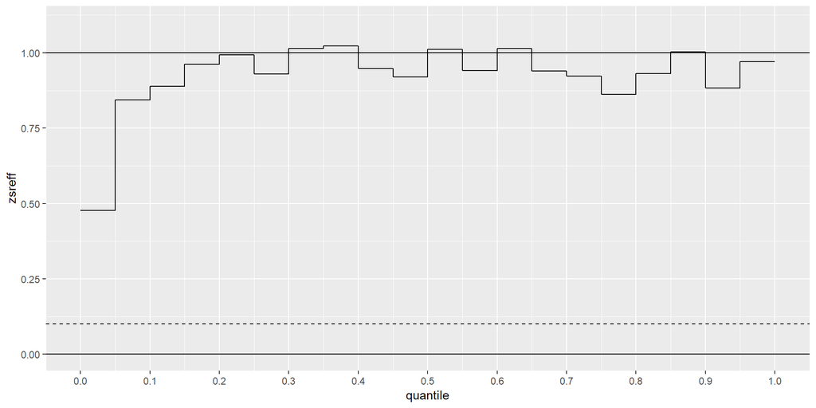

```r
samp <- as.array(fit_ncp2)
plot_local_reff(samp = samp, par = 2, nalpha = 20)
```

Small tau values are still more difficult to explore, but the relative efficiency is in a good range.

Check with a finer resolution

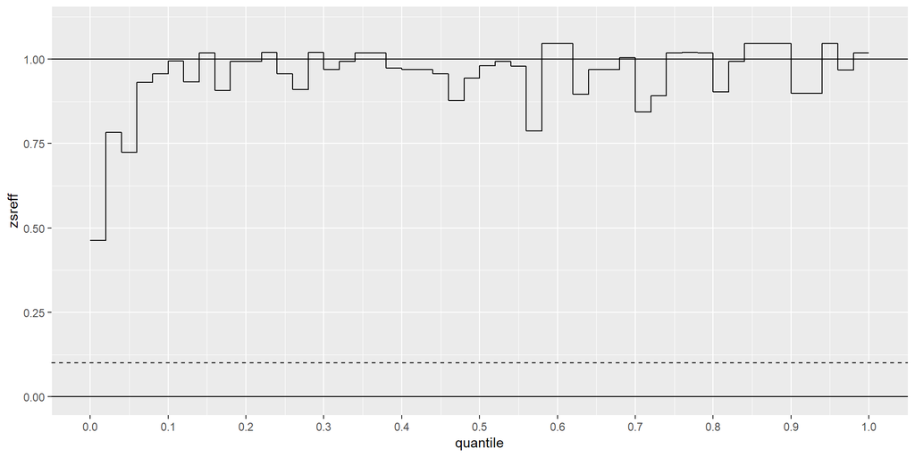

```r
samp <- as.array(fit_ncp2)
plot_local_reff(samp = samp, par = 2, nalpha = 50)
```

Also with a finer resolution the efficiency of MCMC is good for different values of tau.

We examine the relative efficiency of probabilities below quantiles $(0.025, ..., 0.975)$ for `tau`.

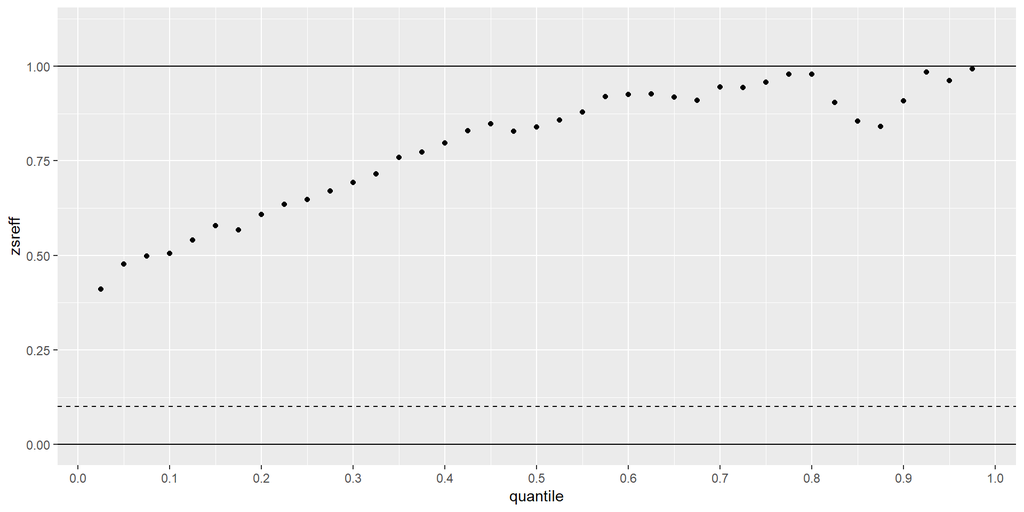

```r
samp <- as.array(fit_ncp2)
plot_quantile_reff(samp = samp, par = 2, nalpha = 40)
```

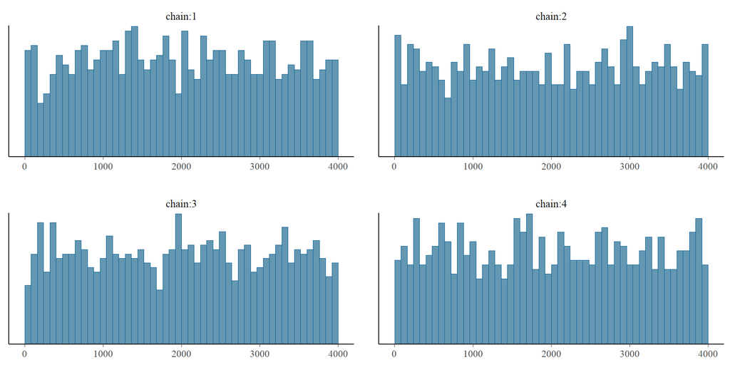

```r
mcmc_hist_r_scale(samp[, , 2])
```

Higher adapt_delta seems to have improved sampling of small values.

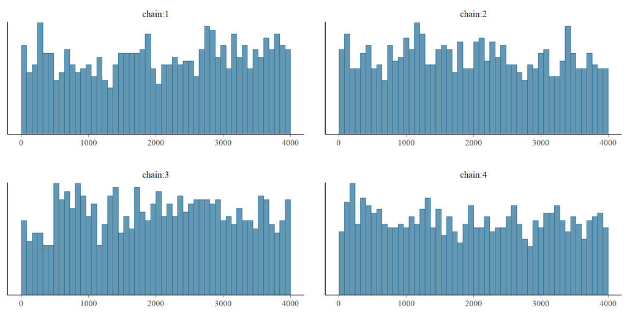

```r
mcmc_hist_r_scale(samp[, , 19])
```

We observe clear problems sampling different energy levels.

If in doubt, we can run longer chains.

```r
input_data <- read_rdump("eight_schools.data.R")
fit_ncp3 <- stan(
  file='eight_schools_ncp.stan', data=input_data,
  iter=20000, chains=4, control=list(adapt_delta = 0.954),
  seed=483892929, refresh=0
)
```

```r
res <- monitor_simple(fit_ncp3)
round(res[, sel], 2)
```

```
               sRhat zsRhat fzsRhat reff zsreff fzsreff medsreff madsreff
mu                 1      1       1 1.04   1.04    0.56     1.06     0.66
tau                1      1       1 0.79   0.62    0.75     0.79     0.73
theta_tilde[1]     1      1       1 1.08   1.08    0.54     1.04     0.64
theta_tilde[2]     1      1       1 1.17   1.17    0.52     1.14     0.61
theta_tilde[3]     1      1       1 1.16   1.16    0.50     1.13     0.57
theta_tilde[4]     1      1       1 1.15   1.15    0.55     1.13     0.64
theta_tilde[5]     1      1       1 1.06   1.06    0.53     1.10     0.61
theta_tilde[6]     1      1       1 1.22   1.22    0.53     1.19     0.60
theta_tilde[7]     1      1       1 1.06   1.07    0.56     1.01     0.62
theta_tilde[8]     1      1       1 1.19   1.19    0.51     1.14     0.61
theta[1]           1      1       1 0.99   1.04    0.69     1.04     0.72
theta[2]           1      1       1 1.26   1.27    0.63     1.15     0.68
theta[3]           1      1       1 1.04   1.08    0.65     1.10     0.69
theta[4]           1      1       1 1.20   1.23    0.67     1.18     0.71
theta[5]           1      1       1 1.16   1.17    0.70     1.13     0.74
theta[6]           1      1       1 1.15   1.18    0.64     1.15     0.69
theta[7]           1      1       1 1.12   1.13    0.72     1.08     0.74
theta[8]           1      1       1 1.04   1.09    0.65     1.10     0.70
lp__               1      1       1 0.42   0.42    0.69     0.51     0.77
```

All Rhats are close to 1, and relative efficiencies are good and slightly better than with the default adapt_delta. Relative efficiency is similar as for shorter chain, which means that running longer chains is giving us higher effective sample size.

We examine the relative efficiency of probabilities between quantiles $(0, 0.05, ..., 1)$ for `tau`.

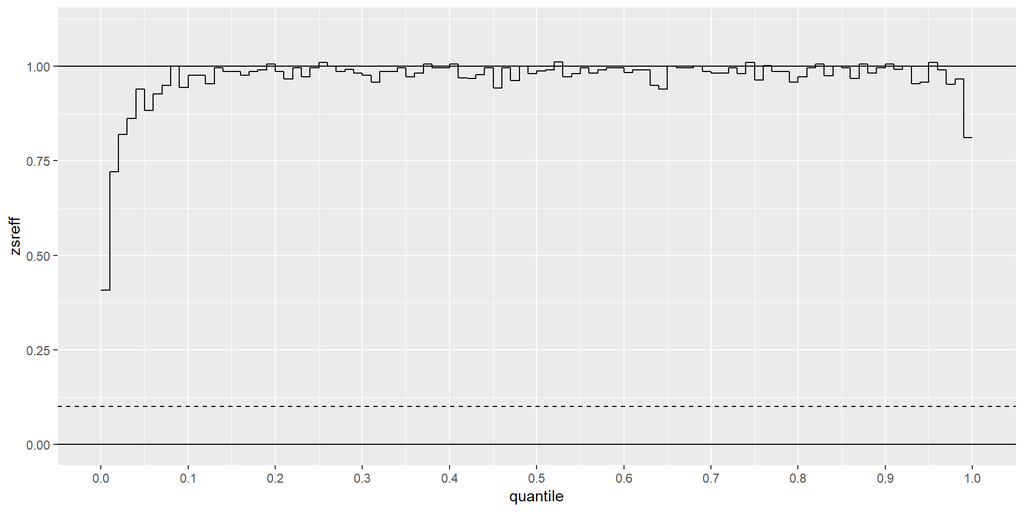

```r
samp <- as.array(fit_ncp3)
plot_local_reff(samp = samp, par = "tau", nalpha = 100)
```

Small `tau` values are still more difficult to explore, but the relative efficiency is in a good range.

We examine the relative efficiency of probabilities below quantiles $(0.01, ..., 0.99)$ for `tau`.

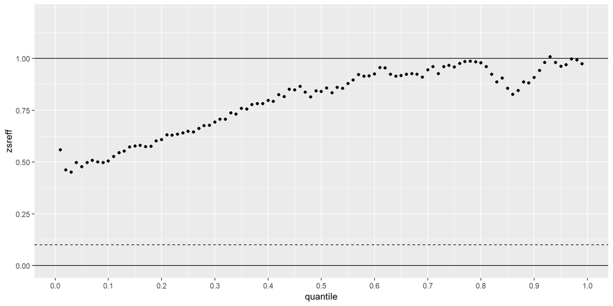

```r
samp <- as.array(fit_ncp2)
plot_quantile_reff(samp = samp, par = "tau", nalpha = 100)
```

[figure not shown]

```r
mcmc_hist_r_scale(samp[, , "tau"])
```

Higher adapt_delta seems to have improved sampling of small values.

Rank plot visualisation of `lp__`, which has a relative efficiency of 0.41.

[figure not shown]

```r
mcmc_hist_r_scale(samp[, , "lp__"])
```

We observe clear problems sampling different energy levels.

## 4.5 NUTS and effective sample size

We have already seen that the relative efficiency of HMC/NUTS can be higher than with independent draws. The next example illustrates interesting relative efficiency phenomena due to properties of the HMC/NUTS algorithm.

```r
writeLines(readLines("normal.stan"))
```

```
data {
  int<lower=1> J;
}
parameters {
  vector[J] x;
}
model {
  x ~ normal(0, 1);
}
```

```r
fit_n <- stan(
  file='normal.stan', data=data.frame(J=16),
  iter=20000, chains=4, seed=483892929, refresh=0
)
```

```r
samp <- as.array(fit_n)
res <- monitor_simple(samp)
round(res[, sel], 2)
```

```
      sRhat zsRhat fzsRhat reff zsreff fzsreff medsreff madsreff
x[1]      1      1       1 2.45   2.46    0.41     2.06     0.48
x[2]      1      1       1 2.39   2.40    0.41     1.89     0.48
x[3]      1      1       1 2.46   2.47    0.40     1.97     0.47
x[4]      1      1       1 2.42   2.43    0.40     2.03     0.48
x[5]      1      1       1 2.53   2.54    0.42     2.00     0.50
x[6]      1      1       1 2.40   2.41    0.41     1.98     0.49
x[7]      1      1       1 2.39   2.40    0.43     2.04     0.49
x[8]      1      1       1 2.50   2.51    0.41     1.98     0.47
x[9]      1      1       1 2.52   2.53    0.40     2.03     0.47
x[10]     1      1       1 2.55   2.58    0.41     1.92     0.48
x[11]     1      1       1 2.38   2.40    0.40     1.98     0.46
x[12]     1      1       1 2.45   2.46    0.38     2.05     0.47
x[13]     1      1       1 2.44   2.45    0.38     2.02     0.46
x[14]     1      1       1 2.42   2.43    0.41     1.94     0.48
x[15]     1      1       1 2.37   2.38    0.42     2.01     0.49
x[16]     1      1       1 2.49   2.50    0.41     2.06     0.47
lp__      1      1       1 0.37   0.36    0.54     0.43     0.59
```

Let’s check the local relative efficiency.

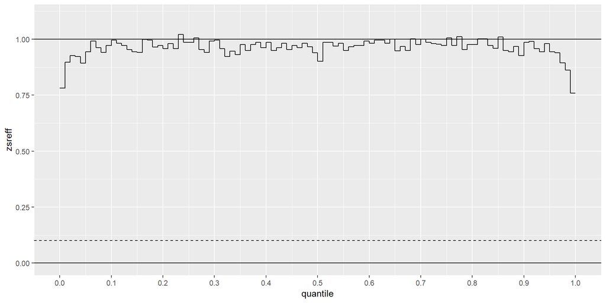

```r
plot_local_reff(samp = samp, par = 1, nalpha = 100)
```

The relative efficiency for probability estimate for a small interval is close to 1 with a slight drop in the tails. This is a good result, but far from the relative efficiency for mean estimate.

Let’s check the relative efficiency of cumulative probabilities.

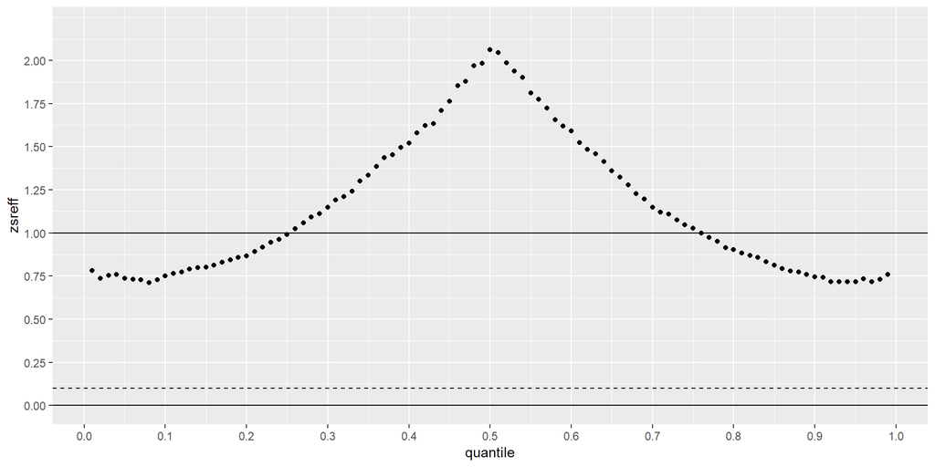

```r
plot_quantile_reff(samp = samp, par = 1, nalpha = 100)
```

The total energy of HMC should affect how far in the tails a chain in one iteration can go. Fat tails of the target have high energy, and thus only chains with high total energy can reach there. This will suggest that the random walk in total energy would cause random walk in variance of x. Let’s check the second moment of x.

```r
samp <- as.array(fit_n, pars = "x")^2
res <- monitor_simple(samp)
round(res[, sel], 2)
```

```
      sRhat zsRhat fzsRhat reff zsreff fzsreff medsreff madsreff
x[1]      1      1       1 0.37   0.41    0.46     0.48     0.58
x[2]      1      1       1 0.39   0.41    0.49     0.48     0.62
x[3]      1      1       1 0.37   0.40    0.46     0.47     0.60
x[4]      1      1       1 0.36   0.40    0.47     0.48     0.60
x[5]      1      1       1 0.38   0.42    0.49     0.50     0.63
x[6]      1      1       1 0.36   0.41    0.44     0.49     0.57
x[7]      1      1       1 0.39   0.43    0.48     0.49     0.58
x[8]      1      1       1 0.37   0.41    0.47     0.47     0.60
x[9]      1      1       1 0.34   0.40    0.46     0.47     0.55
x[10]     1      1       1 0.37   0.41    0.46     0.48     0.60
x[11]     1      1       1 0.38   0.40    0.49     0.46     0.62
x[12]     1      1       1 0.36   0.38    0.47     0.46     0.60
x[13]     1      1       1 0.34   0.38    0.46     0.46     0.60
x[14]     1      1       1 0.36   0.41    0.47     0.48     0.59
x[15]     1      1       1 0.39   0.42    0.49     0.49     0.61
x[16]     1      1       1 0.39   0.41    0.50     0.47     0.61
```

Mean of the relative efficiencies for $x_j^2$ is 0.41, which is quite close to the relative efficiency for `lp__`. This is not that surprising as the potential energy in normal model is relative to $\sum_{j=1}^J x_j^2$.